# Пакет igraph

Ахмедушка

### Установка и подгрузка пакета igraph

```
# install.packages('igraph')
library('igraph')
```

Мы привыкли, что для нас граф это матрица смежности. И мы работаем только с ней. Но пакеты, которые работают с графами делают свои объекты, с которыми мы потом непосредственно работаем. Такой объект можно составить из матрицы смежности или с помощью списка ребёр.

```
M <- matrix(c(0,0,0,1,0,
              0,0,1,1,0,
              0,1,0,1,1,
              1,1,1,0,0,
              0,1,0,0,0),nrow = 5, ncol = 5)
print(M)
```

```
##      [,1] [,2] [,3] [,4] [,5]
## [1,]    0    0    0    1    0
## [2,]    0    0    1    1    1
## [3,]    0    1    0    1    0
## [4,]    1    1    1    0    0
## [5,]    0    0    1    0    0
```

```
g1 <- graph.adjacency(M, weighted = TRUE,mode = 'undirected')
print(g1)
```

```
## IGRAPH 167ecb0 U-W- 5 6 --
## + attr: weight (e/n)
## + edges from 167ecb0:
## [1] 1--4 2--3 2--4 2--5 3--4 3--5
```

Аналогично, можно создать граф из списка рёбер. Важно, чтобы на входе подавалась матрица, не data frame. Также имеется параметр `directed`, отвечающий за ориентированность графа. Название вершин может быть и строковой переменной.

```
L <- data.frame(name1 = c("Jessie", "Jessie", "Sidney","Karl"),
                name2 = c("Sidney", "Britt", "Britt","Sidney"))
g2 <- graph.edgelist(as.matrix(L), directed = FALSE)
```

Изобразим оба графа!

```
plot(g1)
```

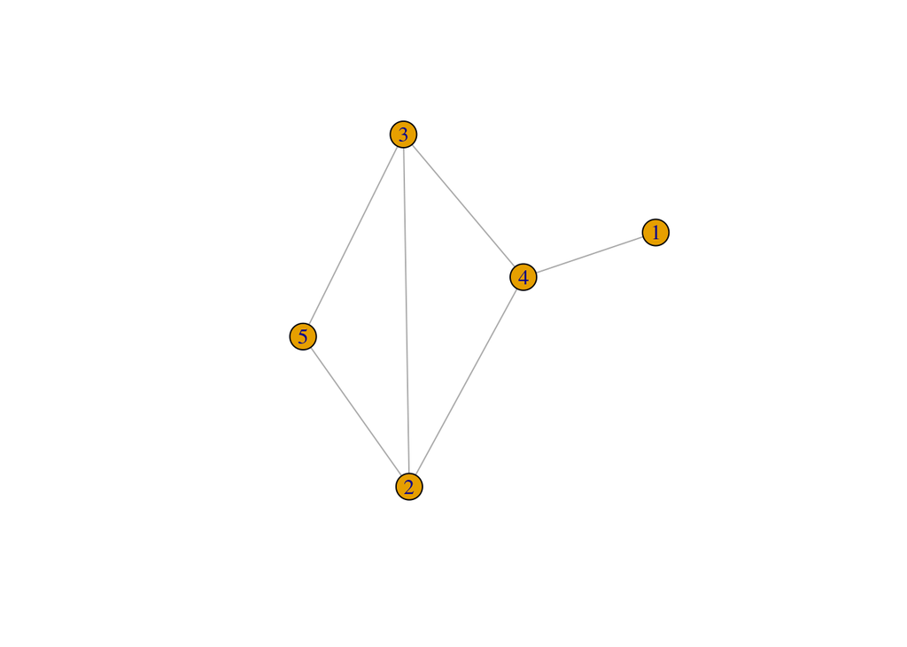

```
plot(g2)
```

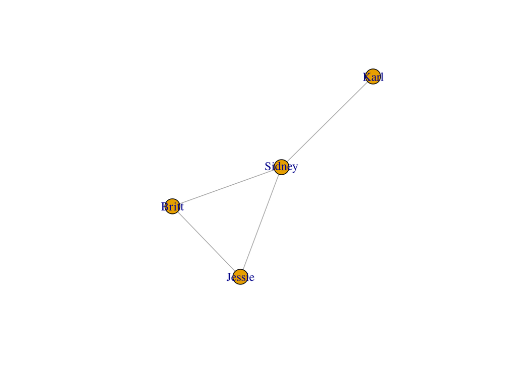

Несколько полезных функций:

- `V(g)` - список вершин
- `E(g)` - список ребер
- `gsize(g)` - количество ребер
- `gorder(g)` - количество вершин
- `add_edges` - добавление ребер
- `add_vertices` - добавление вершин

```
V(g1)
```

```
## + 5/5 vertices, from 167ecb0:
## [1] 1 2 3 4 5
```

```
E(g1)
```

```
## + 6/6 edges from 167ecb0:
## [1] 1--4 2--3 2--4 2--5 3--4 3--5
```

```
gsize(g1)
```

```
## [1] 6
```

```
gorder(g1)
```

```
## [1] 5
```

У вершин графа и его рёбер бывают атрибуты. Например, если вершины графа это люди, то одним из атрибутов является имя. В графе `g2` мы задавали имена вершинам, поэтому этот атрибут у них уже есть. В этом можно убедиться с помощью функции `vertex_attr`.

```
vertex_attr(g2)
```

```
## $name
## [1] "Jessie" "Sidney" "Britt"  "Karl"
```

Еще одним атрибутом вершин может являться возраст. Давайте добавим этот атрибут.

```
g2 <- set_vertex_attr(g2, "age", value = c(16,20,40,25))
vertex_attr(g2)
```

```
## $name
## [1] "Jessie" "Sidney" "Britt"  "Karl"
##
## $age
## [1] 16 20 40 25
```

Главным атрибутом рёбер является вес ребра.

```
edge_attr(g1)
```

```
## $weight
## [1] 1 1 1 1 1 1
```

Но можно добавлять и другие атрибуты.

```
g1 <- set_edge_attr(g1, '1/weight', value = 1/ edge_attr(g1)$weight)
```

Можно просматривать вершины в удобном формате.

```
V(g2)[[]]
```

```
## + 4/4 vertices, named, from d64b294:
##     name age
## 1 Jessie  16
## 2 Sidney  20
## 3  Britt  40
## 4   Karl  25
```

```
V(g2)[[1,3]]
```

```
## + 2/4 vertices, named, from d64b294:
##     name age
## 1 Jessie  16
## 3  Britt  40
```

Можно создавать граф еще одним способом, чтобы учесть все атрибуты сразу, а не добавлять по одному.

```
V <- data.frame(name = c('A', 'B', 'C', 'D', 'E'),
                value = c(20,25,10,19,30))
E <- data.frame(from = c('A','B','C','D'),
                to = c('B','C','D','A'),
                weight = c(1,2,3,4))
g3 <- graph_from_data_frame(d = E, vertices = V, directed = FALSE)
g3
```

```
## IGRAPH f9000b1 UNW- 5 4 --
## + attr: name (v/c), value (v/n), weight (e/n)
## + edges from f9000b1 (vertex names):
## [1] A--B B--C C--D A--D
```

```
vertex_attr(g3)
```

```
## $name
## [1] "A" "B" "C" "D" "E"
##
## $value
## [1] 20 25 10 19 30
```

```
edge_attr(g3)
```

```
## $weight
## [1] 1 2 3 4
```

Можно выделять подграфы.

```
E(g3)[[inc('A')]]
```

```
## + 2/4 edges from f9000b1 (vertex names):
##   tail head tid hid weight
## 1    A    B   1   2      1
## 4    A    D   1   4      4
```

```
E(g3)[[weight>=3]]
```

```
## + 2/4 edges from f9000b1 (vertex names):
##   tail head tid hid weight
## 3    C    D   3   4      3
## 4    A    D   1   4      4
```

Одним из атрибутов вершин может быть их цвет.

```
V(g3)$color <- ifelse(V(g3)$value > 20, 'red', 'white')
plot(g3, vertex.label.color = "blue")
```

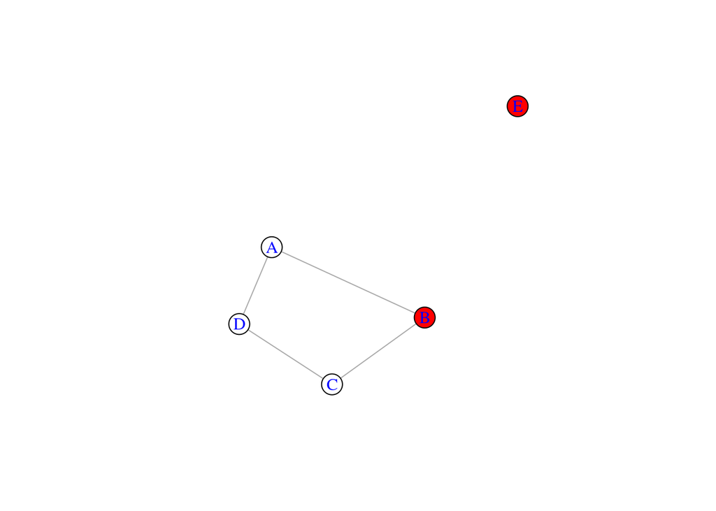

### Визуализация графа

#### plot

Визуализация очень важна. Изучим некоторые опции, которые нам доступны.

- `vertex.color` - цвет вершин
- `edge.color` - цвет ребёр
- `label.color` - цвет названий вершин
- `vertex.size` - размер вершин
- `edge.width` - размер рёбер
- `label.cex` - размер названий вершин

Многие функции могут быть постоянным значением или зависеть от значений в массиве.

- `layout` - это способ рисовки графа. Различные способы представлены на картинке ниже.

[figure not shown]

Если не знаете, что выбрать, то можно поставить значение `layout_nicely`(стоит по умолчанию). Тогда график будет нарисован оптимально.

#### tkplot и graphjs

Обычный `plot` рисует статические графики, это бывает хорошо, когда граф большой. Если граф маленький или средний(если большой, то можно кластеризовать и посмотреть уже на кластеры), то можно нарисовать интерактивный граф. Функция `tkplot` встроена в пакет `igraph`. Вы можете запустить следующий код у себя в скрипте или консоли.

```
# tkplot(sample_k_regular(20,3), vertex.color = 'orange')
```

Там вы можете менять расположение ребер, менять цвет вершин и многое другое. Данная функция позволяет увидеть граф в 2D. Чтобы смотреть на графы в 3D можно использовать функцию `graphjs`, которая находится в пакете `threejs`.

```
# install.packages('threejs')
library('threejs')
```

[interactive chart not shown]

Этот график построен на основе js, поэтому вы можете двигать его даже в онлайн скрипте.

### Граф моих друзей в vk

Нам понадобятся некоторые пакеты, поэтом подгрузим их.

```
library('dplyr')
library('stringr')
```

Данные были выкачаны с помощью VK API через python.

```
data <- read.csv('edges.csv') %>% select(name_1, name_2)
```

Перед нами список рёбер. Создадим граф!

```
graph_vk <- graph.edgelist(as.matrix(data), directed = FALSE)
graph_vk
```

```
## IGRAPH 5431a99 UN-- 475 7394 --
## + attr: name (v/c)
## + edges from 5431a99 (vertex names):
##  [1] Зарманбетов Ахмед--Матросова Ксения
##  [2] Зарманбетов Ахмед--Генералов Дмитрий
##  [3] Зарманбетов Ахмед--Чухров Никита
##  [4] Зарманбетов Ахмед--Емельянов Дмитрий
##  [5] Зарманбетов Ахмед--Барышников Владислав
##  [6] Зарманбетов Ахмед--Ульянкин Филипп
##  [7] Зарманбетов Ахмед--Бобылева Маша
##  [8] Зарманбетов Ахмед--Маруева Катерина
## + ... omitted several edges
```

Попробуем нарисовать этот граф. Но для начала отметим меня красным цветом, а всех остальных оражевым. Это будет нужно, чтобы понимать как расположены кластеры.

```
V(graph_vk)$color = ifelse(V(graph_vk)$name == 'Зарманбетов Ахмед', 'red', 'orange')
```

```
plot(graph_vk)
```

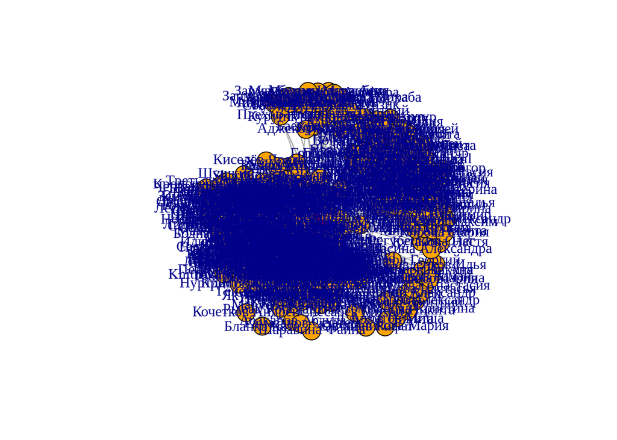

Ничего не понятно, так как граф очень большой. Давайте уберем названия вершин.

```
plot(graph_vk, vertex.label = NA)
```

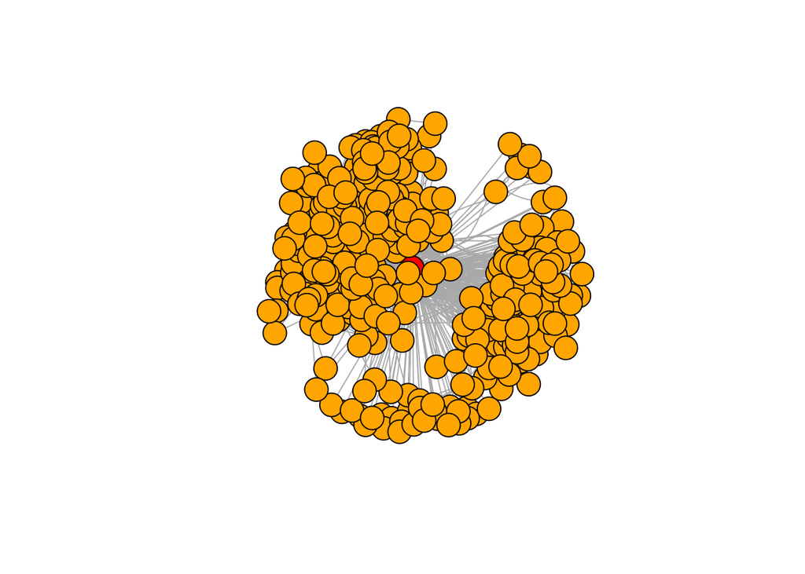

Сами вершины тоже очень большие, поэтому уменьшим их размер.

```
plot(graph_vk, vertex.label = NA, vertex.size = 3)
```

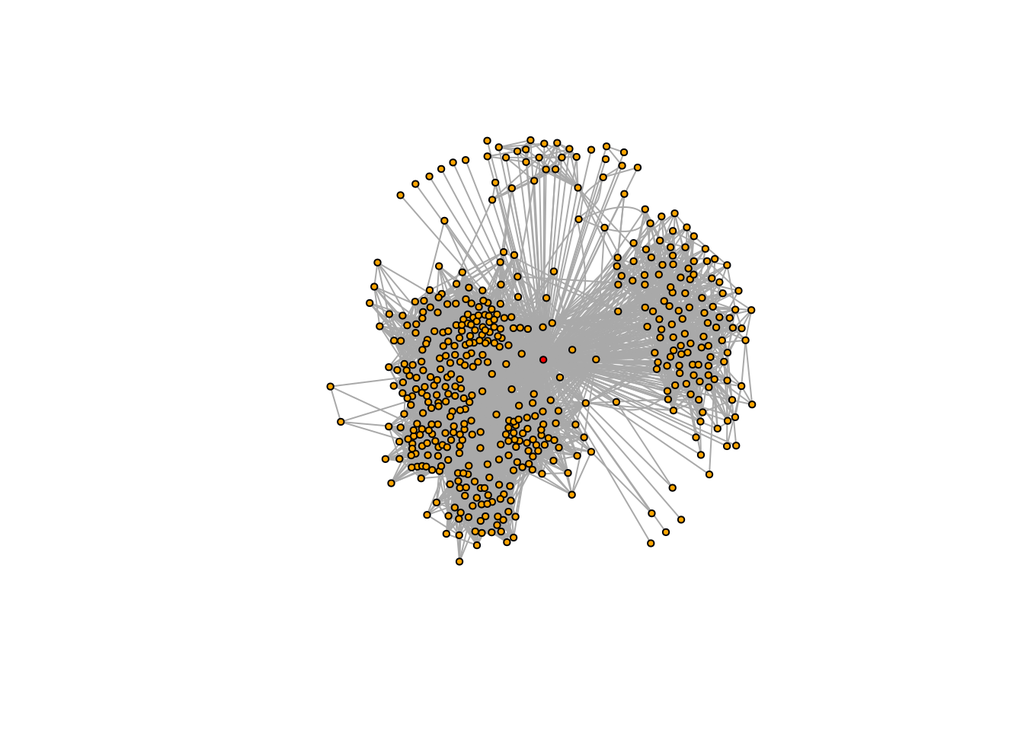

Так лучше, но лучше сохранить этот график с названиями в формате png очень большого размера. Эти графики есть в папке с этим же файликом. Откройте их и увеличьте масштаб.

Можно увидеть, что имеется несколько кластеров:

- кластер моих друзей и знакомых в Туле
- кластер моих друзей и знакомых в Москве(в основом из Ранха)
- кластер родственников

Но внутри второго кластера видно деление на мелкие кластеры(курсы:1,2,3,4).

### Алгоритмы

В пакете реализовано много алгоритмов:

- поиск в ширину - `bfs`
- поиск в глубину - `dfs`
- алгоритм Дейкстры - `shortest_paths`
- и многие другие(в том числе различные кластеризации)